# Instagram reels: A data story

STATS 220 Semester One 2025

Cormac Turley

2025-05-16

## Introduction

The focus of my data collection was on Instagram reels, particularly those on your for you page. Specifically what was observed was each time someone looks at an Instagram reel to observe and write down key features of the reel. These were: the reel time of day, the length of reel, the reel type, the media type and the kind of audio. The observations obtained were mostly my own with some minor assistance from a friend answering the google form a handful of times aswell.

## How might we use different variables to create informative visualizations?

For this visualisation I was interested in how the time of day effects how many Instagram reels were watched. The reason for doing so was I was interested in seeing if we saw spikes at certain time of day and/or if people consume more reels as the day goes on, perhaps due to fatigue and increased seek for comfort at the end of the day.

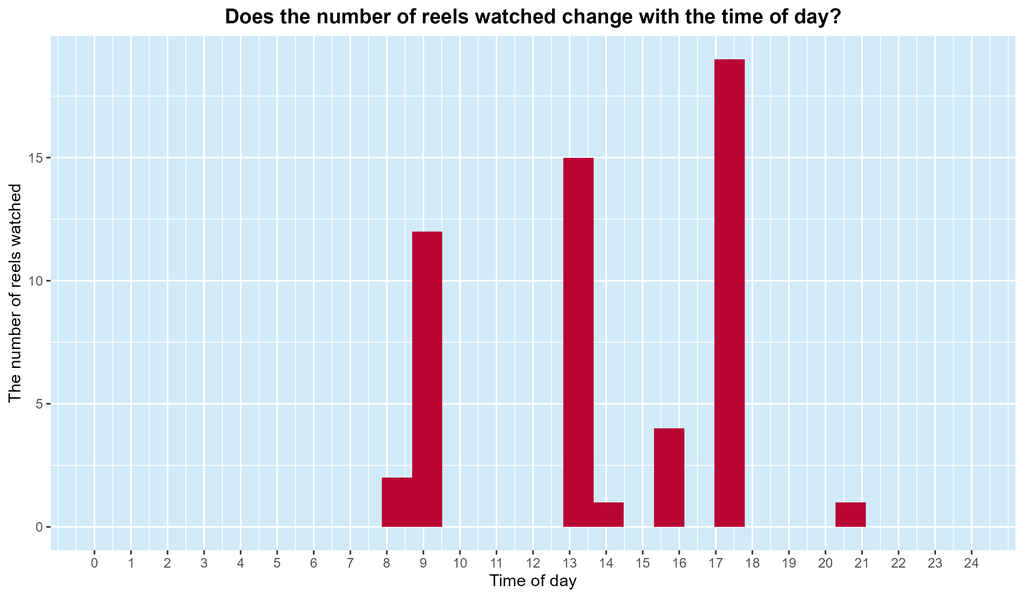

Histogram showing peak Instagram reel consumption by the hour

## Types of reel and how they change in popularity throughout the day.

This visualization was a natural follow on from the previous one. Having seen how there were spikes in reel consumption, I thought it might be interesting to see how the popularity of certain types of reels rose and fell througout the day. I hypothesised that maybe we might see more Educational reels at the start of the day as people were likely to be awake and alert, willing to engage in more informative content. And likewise that we might see more Entertaining reels as the day turned to night as again fatigue set in and people sought out comfort.

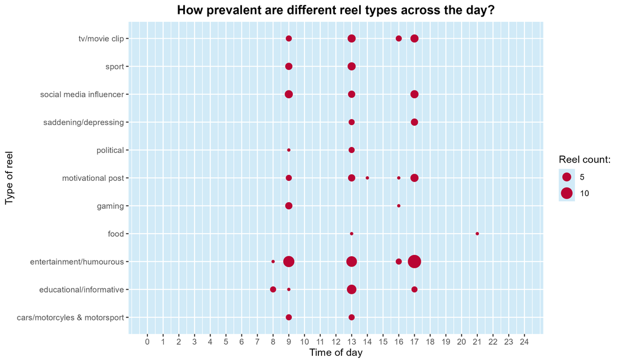

Geom_point showing popularity of different reel types by the hour

## Reel length and how it may be influenced by the time period.

As has been a fixture in my visualisations, we again look at how a variable is effected over time. In this case for the final visualisation, I had one more important follow up question, given that I thought it might be possible that the amount of and the types of reel were effected by time, it seems like a logical next step to ask does the length of reels change over the course of the day. Fitting with my earlier hypotheses, again I think that its possible it decreases as the day goes on, again due to human fatigue and interest in shorter reels.

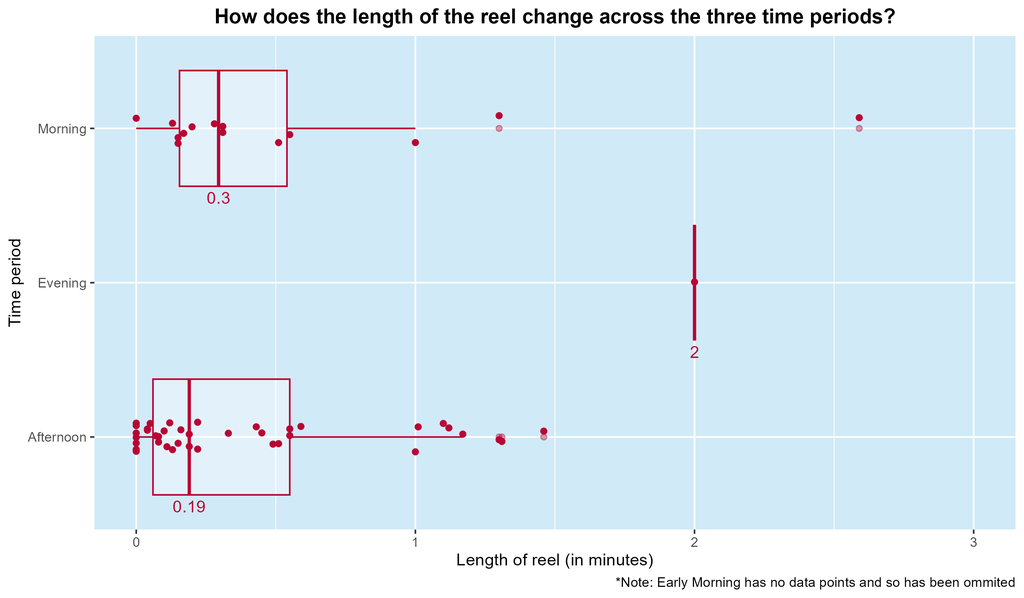

A boxplot showing how the length of reels changed by time period, included median